# MACHINE LEARNING WITH CARET

Joseph Rickert

5/19/16

caret (short for Classification and REgression Training) is the most feature rich package for doing machine learning in R. It provides functions to streamline the entire process and includes tools for:  
* data splitting  
* pre-processing  
* feature selection  
* model tuning using resampling  
* variable importance estimation

This script explores caret’s capabilities using a cell segmentation data set that is included in the package. The data is described in the paper: Hill et al “Impact of image segmentation on high-content screening data quality for SK-BR-3 cells” BMC fioinformatics (2007) vol 8 (1) pp. 340

The analysis presented here is based on examples presented by Max Kuhn, caret’s author, at Use-R 2012.

### Background

“Well-segmented”" cells are cells for which location and size may be accurrately detremined through optical measurements. Cells that are not Well-segmented (WS) are said to be “Poorly-segmented”" (PS). Given a set of optical measurements can we predict which cells will be PS? This is a classic classification problem

### Packages Required

```r
library(caret)
```

```r
library(corrplot)           # plot correlations
library(doParallel)     # parallel processing
library(dplyr)         # Used by caret
library(gbm)                  # Boosting algorithms
library(kernlab)      # support vector machine
library(partykit)           # Plotting trees
library(pROC)                 # plot the ROC curve
library(rpart)              # CART algorithm for decision trees
```

### Get the Data

Load the data and construct indices to divied it into training and test data sets.

```r
data(segmentationData)      # Load the segmentation data set
dim(segmentationData)
```

```
## [1] 2019   61
```

```r
head(segmentationData,2)
```

```
##        Cell  Case Class AngleCh1 AreaCh1 AvgIntenCh1 AvgIntenCh2
## 1 207827637  Test    PS 143.2477     185    15.71186    4.954802
## 2 207932307 Train    PS 133.7520     819    31.92327  206.878517
##   AvgIntenCh3 AvgIntenCh4 ConvexHullAreaRatioCh1 ConvexHullPerimRatioCh1
## 1    9.548023    2.214689               1.124509               0.9196827
## 2   69.916880  164.153453               1.263158               0.7970801
##   DiffIntenDensityCh1 DiffIntenDensityCh3 DiffIntenDensityCh4
## 1            29.51923            13.77564            6.826923
## 2            31.87500            43.12228           79.308424
##   EntropyIntenCh1 EntropyIntenCh3 EntropyIntenCh4 EqCircDiamCh1
## 1        4.969781        4.371017        2.718884      15.36954
## 2        6.087592        6.642761        7.880155      32.30558
##   EqEllipseLWRCh1 EqEllipseOblateVolCh1 EqEllipseProlateVolCh1
## 1        3.060676              336.9691               110.0963
## 2        1.558394             2232.9055              1432.8246
##   EqSphereAreaCh1 EqSphereVolCh1 FiberAlign2Ch3 FiberAlign2Ch4
## 1        742.1156       1900.996       1.000000       1.000000
## 2       3278.7256      17653.525       1.487935       1.352374
##   FiberLengthCh1 FiberWidthCh1 IntenCoocASMCh3 IntenCoocASMCh4
## 1       26.98132      7.410365      0.01118390      0.05044801
## 2       64.28230     13.167079      0.02805106      0.01259498
##   IntenCoocContrastCh3 IntenCoocContrastCh4 IntenCoocEntropyCh3
## 1            40.751777            13.895439            7.199458
## 2             8.227953             6.984046            6.822138
##   IntenCoocEntropyCh4 IntenCoocMaxCh3 IntenCoocMaxCh4 KurtIntenCh1
## 1            5.249744      0.07741935      0.17197452   -0.6567441
## 2            7.098988      0.15321477      0.07387141   -0.2487691
##   KurtIntenCh3 KurtIntenCh4 LengthCh1 NeighborAvgDistCh1
## 1   -0.6080583    0.7258145  26.20779           370.4543
## 2   -0.3307839   -0.2652638  47.21855           174.4442
##   NeighborMinDistCh1 NeighborVarDistCh1  PerimCh1 ShapeBFRCh1 ShapeLWRCh1
## 1           99.10349          127.96080  68.78338   0.6651480    2.462450
## 2           30.11114           81.38063 154.89876   0.5397584    1.468181
##   ShapeP2ACh1 SkewIntenCh1 SkewIntenCh3 SkewIntenCh4 SpotFiberCountCh3
## 1    1.883006    0.4545048    0.4603934    1.2327736                 1
## 2    2.255810    0.3987047    0.6197308    0.5272631                 4
##   SpotFiberCountCh4 TotalIntenCh1 TotalIntenCh2 TotalIntenCh3
## 1                 5          2781           701          1690
## 2                12         24964        160998         54675
##   TotalIntenCh4 VarIntenCh1 VarIntenCh3 VarIntenCh4 WidthCh1 XCentroid
## 1           392    12.47468    7.609035      2.7141 10.64297        42
## 2        128368    18.80923   56.715352    118.3881 32.16126       215
##   YCentroid
## 1        14
## 2       347
```

```r
#
trainIndex <- createDataPartition(segmentationData$Case,p=.5,list=FALSE)
trainData <- segmentationData[trainIndex,-c(1,2)]
testData  <- segmentationData[-trainIndex,-c(1,2)]
#
trainX <-trainData[,-1]        # Pull out the dependent variable
testX <- testData[,-1]
```

## GENERALIZED BOOSTED REGRGRESSION MODEL

We build a gbm model. Note that the gbm function does not allow factor “class” variables

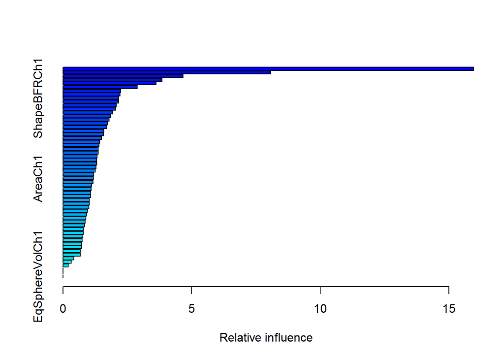

```
##                                             var    rel.inf
## TotalIntenCh2                     TotalIntenCh2 15.9675399
## FiberWidthCh1                     FiberWidthCh1  8.0800992
## AvgIntenCh1                         AvgIntenCh1  4.6618948
## AvgIntenCh2                         AvgIntenCh2  3.8577460
## ShapeP2ACh1                         ShapeP2ACh1  3.6170720
## TotalIntenCh1                     TotalIntenCh1  2.8871437
## XCentroid                             XCentroid  2.2458585
## KurtIntenCh1                       KurtIntenCh1  2.2212311
## ShapeBFRCh1                         ShapeBFRCh1  2.1628016
## ConvexHullAreaRatioCh1   ConvexHullAreaRatioCh1  2.1565338
## ConvexHullPerimRatioCh1 ConvexHullPerimRatioCh1  2.0747470
## SkewIntenCh1                       SkewIntenCh1  2.0446700
## IntenCoocContrastCh3       IntenCoocContrastCh3  1.9329994
## TotalIntenCh3                     TotalIntenCh3  1.8546494
## DiffIntenDensityCh4         DiffIntenDensityCh4  1.7994754
## EntropyIntenCh1                 EntropyIntenCh1  1.7320466
## TotalIntenCh4                     TotalIntenCh4  1.7075871
## KurtIntenCh4                       KurtIntenCh4  1.5940646
## IntenCoocContrastCh4       IntenCoocContrastCh4  1.5745370
## AngleCh1                               AngleCh1  1.5002427
## NeighborAvgDistCh1           NeighborAvgDistCh1  1.4268214
## VarIntenCh4                         VarIntenCh4  1.4029157
## SkewIntenCh4                       SkewIntenCh4  1.3701847
## DiffIntenDensityCh3         DiffIntenDensityCh3  1.3671563
## WidthCh1                               WidthCh1  1.3316243
## FiberAlign2Ch3                   FiberAlign2Ch3  1.3211802
## VarIntenCh1                         VarIntenCh1  1.3074803
## YCentroid                             YCentroid  1.2920013
## KurtIntenCh3                       KurtIntenCh3  1.2541049
## EqEllipseProlateVolCh1   EqEllipseProlateVolCh1  1.1938141
## AreaCh1                                 AreaCh1  1.1805088
## NeighborMinDistCh1           NeighborMinDistCh1  1.1616715
## EntropyIntenCh4                 EntropyIntenCh4  1.1119251
## EqEllipseLWRCh1                 EqEllipseLWRCh1  1.1023590
## LengthCh1                             LengthCh1  1.0796636
## EqEllipseOblateVolCh1     EqEllipseOblateVolCh1  1.0778377
## IntenCoocEntropyCh3         IntenCoocEntropyCh3  1.0251713
## DiffIntenDensityCh1         DiffIntenDensityCh1  1.0206519
## FiberAlign2Ch4                   FiberAlign2Ch4  1.0083904
## AvgIntenCh3                         AvgIntenCh3  0.9649792
## VarIntenCh3                         VarIntenCh3  0.9184021
## EntropyIntenCh3                 EntropyIntenCh3  0.8946254
## IntenCoocEntropyCh4         IntenCoocEntropyCh4  0.8588045
## PerimCh1                               PerimCh1  0.8317879
## NeighborVarDistCh1           NeighborVarDistCh1  0.7915006
## SkewIntenCh3                       SkewIntenCh3  0.7858566
## FiberLengthCh1                   FiberLengthCh1  0.7817380
## IntenCoocMaxCh3                 IntenCoocMaxCh3  0.7397007
## ShapeLWRCh1                         ShapeLWRCh1  0.7219636
## AvgIntenCh4                         AvgIntenCh4  0.7119317
## IntenCoocASMCh4                 IntenCoocASMCh4  0.6671987
## IntenCoocASMCh3                 IntenCoocASMCh3  0.6655900
## SpotFiberCountCh4             SpotFiberCountCh4  0.4286681
## IntenCoocMaxCh4                 IntenCoocMaxCh4  0.3221915
## SpotFiberCountCh3             SpotFiberCountCh3  0.2066592
## EqCircDiamCh1                     EqCircDiamCh1  0.0000000
## EqSphereAreaCh1                 EqSphereAreaCh1  0.0000000
## EqSphereVolCh1                   EqSphereVolCh1  0.0000000
```

```r
gbmTrain <- trainData
gbmTrain$Class <- ifelse(gbmTrain$Class=="PS",1,0)
gbm.mod <- gbm(formula = Class~.,           # use all variables
                distribution = "bernoulli",       # for a classification problem
                data = gbmTrain,
                n.trees = 2000,                         # 2000 boosting iterations
                interaction.depth = 7,              # 7 splits for each tree
                shrinkage = 0.01,                       # the learning rate parameter
                verbose = FALSE)                        # Do not print the details

summary(gbm.mod)            # Plot the relative inference of the variables in the model
```

This is an interesting model, but how do you select the best values for the for the three tuning parameters?  
* n.trees  
* interaction.depth  
* shrinkage

### GBM Model Training Over Paramter Space

caret provides the “train” function that implements the following algorithm:

Algorithm for training the model:  
Define sets of model parameters to evaluate  
for each parameter set do  
….for each resampling iteration do  
……hold out specific samples  
……pre-process the data  
……fit the model to the remainder  
….predict the holdout samples  
….end  
….calculate the average performance across hold-out predictions  
end  
Determine the optimal parameter set  
Fit the final model to the training data using the optimal parameter set

Note the default method of picking the best model is accuracy and Cohen’s Kappa

```r
# Set up training control
ctrl <- trainControl(method="repeatedcv",   # 10fold cross validation
                     repeats=5,                                   # do 5 repititions of cv
                     summaryFunction=twoClassSummary,   # Use AUC to pick the best model
                     classProbs=TRUE)
```

Use the expand.grid to specify the search space Note that the default search grid selects 3 values of each tuning parameter

```r
grid <- expand.grid(interaction.depth = seq(1,4,by=2), #tree depths from 1 to 4
                    n.trees=seq(10,100,by=10),  # let iterations go from 10 to 100
                    shrinkage=c(0.01,0.1),          # Try 2 values fornlearning rate
                    n.minobsinnode = 20)
#
set.seed(1951)                     # set the seed to 1
```

Set up to to do parallel processing

```r
registerDoParallel(4)       # Registrer a parallel backend for train
getDoParWorkers()
```

```
## [1] 4
```

```r
system.time(gbm.tune <- train(x=trainX,y=trainData$Class,
                method = "gbm",
                metric = "ROC",
                trControl = ctrl,
                tuneGrid=grid,
                verbose=FALSE))
```

```
##    user  system elapsed
##    1.37    0.06   29.59
```

Look at the tuning results Note that ROC was the performance criterion used to select the optimal model.

```r
gbm.tune$bestTune
```

```
##    n.trees interaction.depth shrinkage n.minobsinnode
## 37      70                 3       0.1             20
```

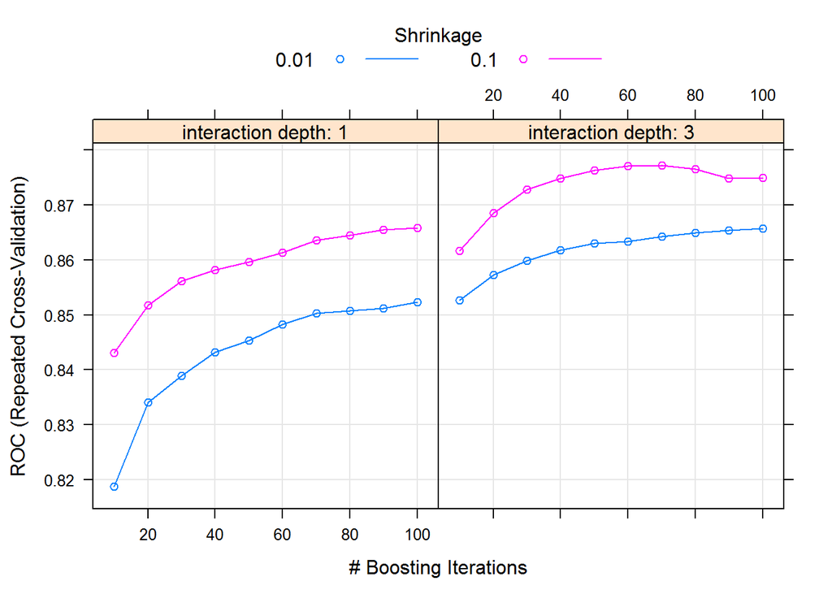

```r
plot(gbm.tune)          # Plot the performance of the training models
```

```r
res <- gbm.tune$results
names(res) <- c("depth","trees", "shrinkage","ROC", "Sens","Spec", "sdROC", "sdSens", "seSpec")
res
```

```
##    depth trees shrinkage ROC      Sens      Spec     sdROC     sdSens
## 1   0.01     1        20  10 0.8187494 1.0000000 0.0000000 0.04694363
## 21  0.10     1        20  10 0.8431074 0.8918155 0.5086486 0.04100066
## 11  0.01     3        20  10 0.8526704 1.0000000 0.0000000 0.03649129
## 31  0.10     3        20  10 0.8617082 0.8899950 0.5944097 0.03862375
## 2   0.01     1        20  20 0.8341098 1.0000000 0.0000000 0.04285034
## 22  0.10     1        20  20 0.8518110 0.8585714 0.6302703 0.03853474
## 12  0.01     3        20  20 0.8572772 1.0000000 0.0000000 0.03683781
## 32  0.10     3        20  20 0.8685652 0.8635913 0.6815363 0.03646141
## 3   0.01     1        20  30 0.8389135 1.0000000 0.0000000 0.04283467
## 23  0.10     1        20  30 0.8561844 0.8488046 0.6574538 0.03698446
## 13  0.01     3        20  30 0.8598800 1.0000000 0.0000000 0.03696254
## 33  0.10     3        20  30 0.8728417 0.8657738 0.7018777 0.03471567
## 4   0.01     1        20  40 0.8431587 1.0000000 0.0000000 0.04305458
## 24  0.10     1        20  40 0.8581640 0.8485020 0.6665434 0.03668974
```

[output cut: 67 more lines]

### GBM Model Predictions and Performance

Make predictions using the test data set

```r
gbm.pred <- predict(gbm.tune,testX)
head(gbm.pred)
```

```
## [1] PS PS WS WS PS PS
## Levels: PS WS
```

Look at the confusion matrix

```r
confusionMatrix(gbm.pred,testData$Class)
```

```
## Confusion Matrix and Statistics
##
##           Reference
## Prediction  PS  WS
##         PS 576  75
##         WS  88 270
##
##                Accuracy : 0.8385
##                  95% CI : (0.8143, 0.8606)
##     No Information Rate : 0.6581
##     P-Value [Acc > NIR] : <2e-16
##
##                   Kappa : 0.6442
##  Mcnemar's Test P-Value : 0.3473
##
##             Sensitivity : 0.8675
##             Specificity : 0.7826
##          Pos Pred Value : 0.8848
##          Neg Pred Value : 0.7542
##              Prevalence : 0.6581
##          Detection Rate : 0.5709
##    Detection Prevalence : 0.6452
##       Balanced Accuracy : 0.8250
##
##        'Positive' Class : PS
##
```

Draw the ROC curve

```r
gbm.probs <- predict(gbm.tune,testX,type="prob")
head(gbm.probs)
```

```
##           PS         WS
## 1 0.74868017 0.25131983
## 2 0.92791702 0.07208298
## 3 0.05055036 0.94944964
## 4 0.06435450 0.93564550
## 5 0.63278380 0.36721620
## 6 0.78290093 0.21709907
```

```r
gbm.ROC <- roc(predictor=gbm.probs$PS,
            response=testData$Class,
                levels=rev(levels(testData$Class)))
gbm.ROC
```

```
##
## Call:
## roc.default(response = testData$Class, predictor = gbm.probs$PS,     levels = rev(levels(testData$Class)))
##
## Data: gbm.probs$PS in 345 controls (testData$Class WS) < 664 cases (testData$Class PS).
## Area under the curve: 0.9129
```

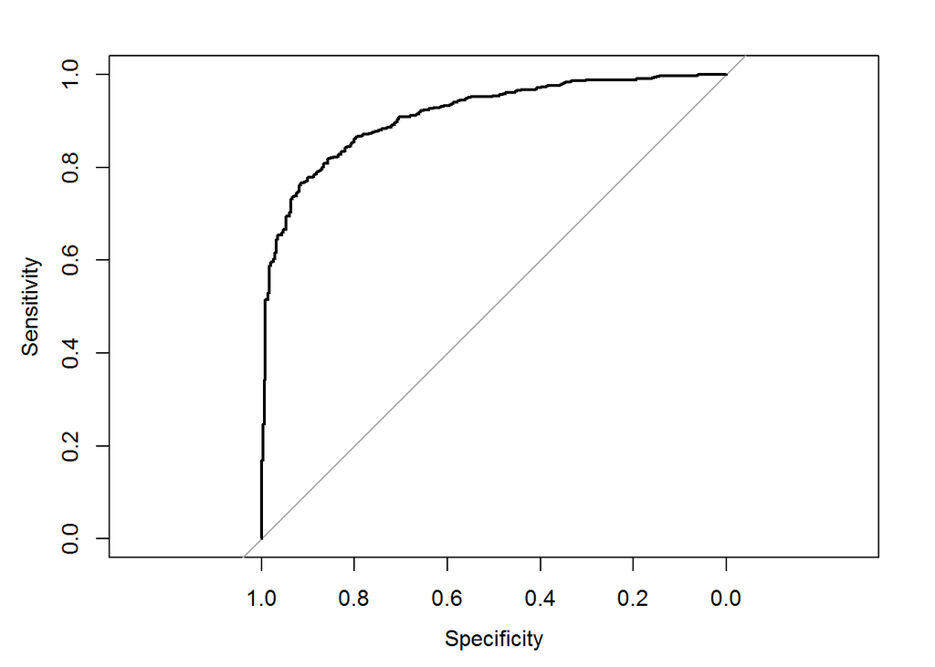

```
##
## Call:
## roc.default(response = testData$Class, predictor = gbm.probs$PS,     levels = rev(levels(testData$Class)))
##
## Data: gbm.probs$PS in 345 controls (testData$Class WS) < 664 cases (testData$Class PS).
## Area under the curve: 0.9129
```

```r
plot(gbm.ROC)
```

Plot the propability of poor segmentation

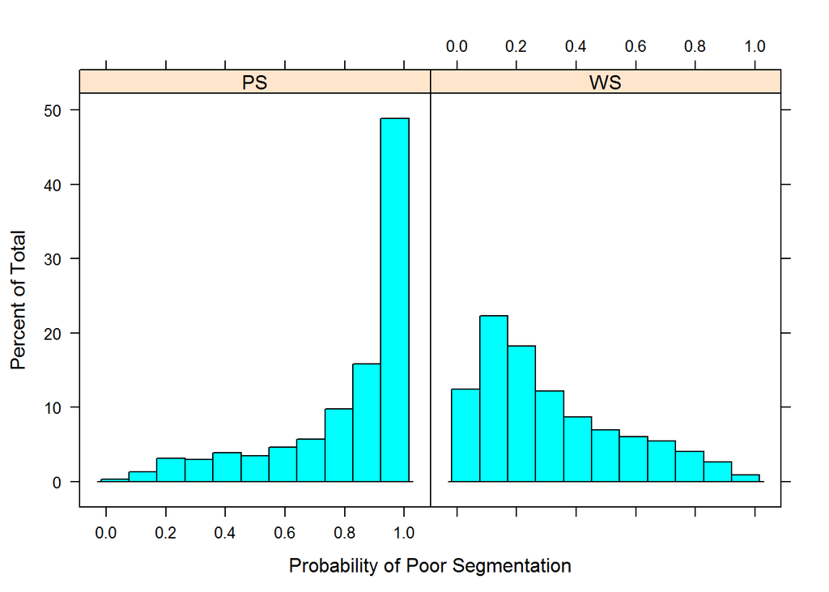

```r
histogram(~gbm.probs$PS|testData$Class,xlab="Probability of Poor Segmentation")
```

## SUPPORT VECTOR MACHINE MODEL

We follow steps similar to those above to build a SVM model

```r
# Set up for parallel procerssing
set.seed(1951)
registerDoParallel(4,cores=4)
getDoParWorkers()
```

```
## [1] 4
```

Train and Tune the SVM

```r
system.time(
  svm.tune <- train(x=trainX,
                    y= trainData$Class,
                    method = "svmRadial",
                    tuneLength = 9,                 # 9 values of the cost function
                    preProc = c("center","scale"),
                    metric="ROC",
                    trControl=ctrl) # same as for gbm above
)
```

```
##    user  system elapsed
##    1.84    0.09   92.65
```

```r
svm.tune
```

```
## Support Vector Machines with Radial Basis Function Kernel
##
## 1010 samples
##   58 predictor
##    2 classes: 'PS', 'WS'
##
## Pre-processing: centered, scaled
## Resampling: Cross-Validated (10 fold, repeated 5 times)
## Summary of sample sizes: 909, 910, 909, 909, 909, 909, ...
## Resampling results across tuning parameters:
##
##   C      ROC        Sens       Spec       ROC SD      Sens SD
##    0.25  0.8653795  0.8607688  0.6917070  0.03311478  0.04013918
##    0.50  0.8684118  0.8698859  0.6958748  0.03137903  0.04253693
##    1.00  0.8725813  0.8755456  0.7071550  0.03009017  0.04235765
##    2.00  0.8715866  0.8805308  0.6952489  0.02995251  0.03661229
##    4.00  0.8650596  0.8817956  0.6872973  0.02983591  0.03760379
##    8.00  0.8524989  0.8714484  0.6637127  0.02997842  0.04251988
##   16.00  0.8389781  0.8676042  0.6263016  0.03335956  0.04074355
##   32.00  0.8221333  0.8600546  0.5940541  0.03588573  0.04429849
##   64.00  0.8138871  0.8563145  0.5765149  0.03647661  0.04272444
##   Spec SD
##   0.07446643
##   0.07265970
##   0.07416980
##   0.06855543
##   0.06551358
##   0.06916015
##   0.06868689
##   0.07875767
##   0.07577691
##
## Tuning parameter 'sigma' was held constant at a value of 0.01463035
## ROC was used to select the optimal model using  the largest value.
## The final values used for the model were sigma = 0.01463035 and C = 1.
```

Plot the SVM results

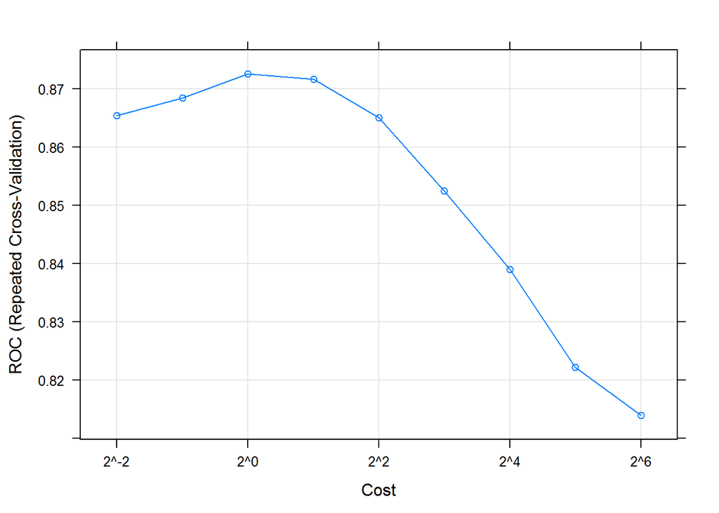

```r
plot(svm.tune,
     metric="ROC",
     scales=list(x=list(log=2)))
```

Make predictions on the test data with the SVM Model

```r
svm.pred <- predict(svm.tune,testX)
head(svm.pred)
```

```
## [1] WS PS WS WS PS PS
## Levels: PS WS
```

```r
confusionMatrix(svm.pred,testData$Class)
```

```
## Confusion Matrix and Statistics
##
##           Reference
## Prediction  PS  WS
##         PS 578  90
##         WS  86 255
##
##                Accuracy : 0.8256
##                  95% CI : (0.8007, 0.8485)
##     No Information Rate : 0.6581
##     P-Value [Acc > NIR] : <2e-16
##
##                   Kappa : 0.6113
##  Mcnemar's Test P-Value : 0.8211
##
##             Sensitivity : 0.8705
##             Specificity : 0.7391
##          Pos Pred Value : 0.8653
##          Neg Pred Value : 0.7478
##              Prevalence : 0.6581
##          Detection Rate : 0.5728
##    Detection Prevalence : 0.6620
##       Balanced Accuracy : 0.8048
##
##        'Positive' Class : PS
##
```

```r
svm.probs <- predict(svm.tune,testX,type="prob")
head(svm.probs)
```

```
##          PS         WS
## 1 0.1269869 0.87301312
## 2 0.9072660 0.09273396
## 3 0.0917118 0.90828820
## 4 0.1099455 0.89005446
## 5 0.5091632 0.49083684
## 6 0.6534494 0.34655061
```

```r
svm.ROC <- roc(predictor=svm.probs$PS,
               response=testData$Class,
               levels=rev(levels(testData$Class)))
svm.ROC
```

```
##
## Call:
## roc.default(response = testData$Class, predictor = svm.probs$PS,     levels = rev(levels(testData$Class)))
##
## Data: svm.probs$PS in 345 controls (testData$Class WS) < 664 cases (testData$Class PS).
## Area under the curve: 0.9062
```

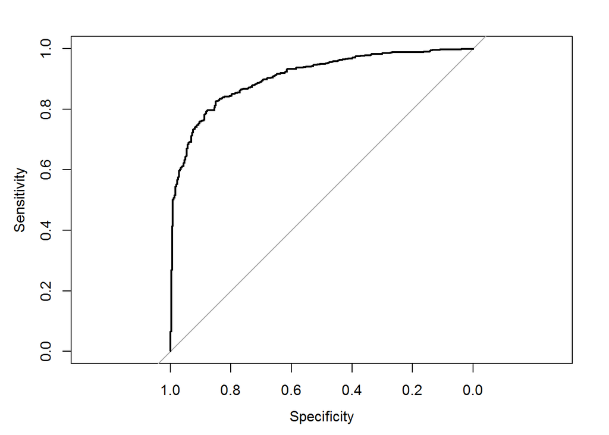

```
##
## Call:
## roc.default(response = testData$Class, predictor = svm.probs$PS,     levels = rev(levels(testData$Class)))
##
## Data: svm.probs$PS in 345 controls (testData$Class WS) < 664 cases (testData$Class PS).
## Area under the curve: 0.9062
```

```r
plot(svm.ROC)
```

## RANDOM FOREST MODEL

```r
set.seed(1951)
rf.tune <-train(x=trainX,
                y= trainData$Class,
                method="rf",
                trControl= ctrl,
                prox=TRUE,allowParallel=TRUE)
rf.tune
```

```
## Random Forest
##
## 1010 samples
##   58 predictor
##    2 classes: 'PS', 'WS'
##
## No pre-processing
## Resampling: Cross-Validated (10 fold, repeated 5 times)
## Summary of sample sizes: 909, 910, 909, 909, 909, 909, ...
## Resampling results across tuning parameters:
##
##   mtry  ROC        Sens       Spec       ROC SD      Sens SD
##    2    0.8849756  0.8846280  0.7077240  0.03092684  0.03568118
##   30    0.8835891  0.8629613  0.7285917  0.02990504  0.04145772
##   58    0.8777743  0.8610615  0.7317781  0.03051491  0.03947482
##   Spec SD
##   0.06643677
##   0.07035759
##   0.07451445
##
## ROC was used to select the optimal model using  the largest value.
## The final value used for the model was mtry = 2.
```

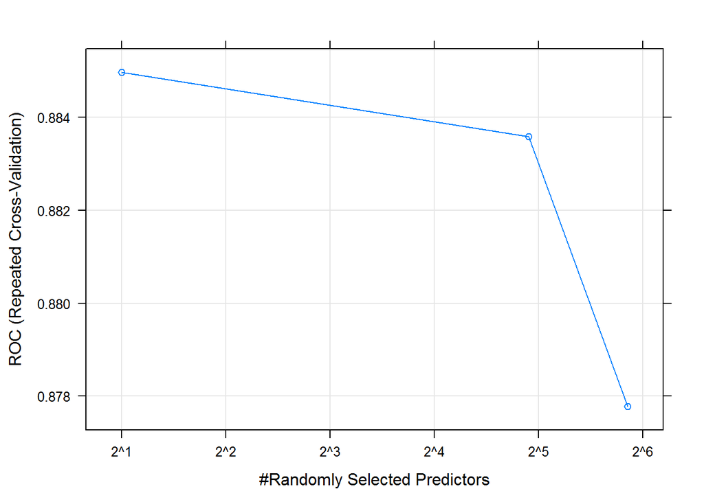

```r
# Plot the Random Forest results
plot(rf.tune,
     metric="ROC",
     scales=list(x=list(log=2)))
```

```r
# Random Forest Predictions
rf.pred <- predict(rf.tune,testX)
head(rf.pred)
```

```
## [1] PS PS WS WS PS PS
## Levels: PS WS
```

```r
confusionMatrix(rf.pred,testData$Class)
```

```
## Confusion Matrix and Statistics
##
##           Reference
## Prediction  PS  WS
##         PS 579  83
##         WS  85 262
##
##                Accuracy : 0.8335
##                  95% CI : (0.8091, 0.856)
##     No Information Rate : 0.6581
##     P-Value [Acc > NIR] : <2e-16
##
##                   Kappa : 0.6305
##  Mcnemar's Test P-Value : 0.9385
##
##             Sensitivity : 0.8720
##             Specificity : 0.7594
##          Pos Pred Value : 0.8746
##          Neg Pred Value : 0.7550
##              Prevalence : 0.6581
##          Detection Rate : 0.5738
##    Detection Prevalence : 0.6561
##       Balanced Accuracy : 0.8157
##
##        'Positive' Class : PS
##
```

```r
rf.probs <- predict(rf.tune,testX,type="prob")
head(rf.probs)
```

```
##       PS    WS
## 3  0.542 0.458
## 4  0.882 0.118
## 6  0.090 0.910
## 7  0.082 0.918
## 9  0.538 0.462
## 10 0.808 0.192
```

```r
rf.ROC <- roc(predictor=rf.probs$PS,
               response=testData$Class,
               levels=rev(levels(testData$Class)))
rf.ROC
```

```
##
## Call:
## roc.default(response = testData$Class, predictor = rf.probs$PS,     levels = rev(levels(testData$Class)))
##
## Data: rf.probs$PS in 345 controls (testData$Class WS) < 664 cases (testData$Class PS).
## Area under the curve: 0.9124
```

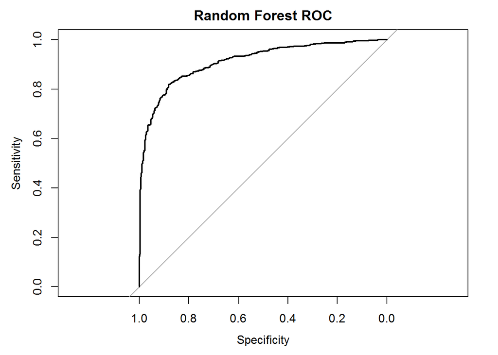

```
##
## Call:
## roc.default(response = testData$Class, predictor = rf.probs$PS,     levels = rev(levels(testData$Class)))
##
## Data: rf.probs$PS in 345 controls (testData$Class WS) < 664 cases (testData$Class PS).
## Area under the curve: 0.9124
```

```r
plot(rf.ROC,main = "Random Forest ROC")
```

## Comparing Multiple Models

```r
rValues <- resamples(list(svm=svm.tune,gbm=gbm.tune,rf=rf.tune))
rValues$values
```

```
##       Resample   svm~ROC  svm~Sens  svm~Spec   gbm~ROC  gbm~Sens  gbm~Spec
## 1  Fold01.Rep1 0.8602196 0.7968750 0.7297297 0.8576858 0.8281250 0.7027027
## 2  Fold01.Rep2 0.8804899 0.9375000 0.6486486 0.8703547 0.8750000 0.7027027
## 3  Fold01.Rep3 0.8545689 0.8571429 0.7837838 0.8537109 0.7936508 0.8108108
## 4  Fold01.Rep4 0.8834459 0.9062500 0.7027027 0.9066723 0.8593750 0.7297297
## 5  Fold01.Rep5 0.9066612 0.8281250 0.8421053 0.8980263 0.7968750 0.7894737
## 6  Fold02.Rep1 0.8807379 0.8888889 0.7297297 0.8768769 0.8095238 0.7567568
## 7  Fold02.Rep2 0.8521959 0.8125000 0.8108108 0.8606419 0.8125000 0.7297297
## 8  Fold02.Rep3 0.7882206 0.8412698 0.5263158 0.7823726 0.8253968 0.4473684
## 9  Fold02.Rep4 0.8947368 0.8906250 0.6578947 0.8885691 0.8593750 0.7894737
## 10 Fold02.Rep5 0.8777349 0.7936508 0.7567568 0.8743029 0.8095238 0.8108108
## 11 Fold03.Rep1 0.9035088 0.9047619 0.6578947 0.9039265 0.9206349 0.7105263
## 12 Fold03.Rep2 0.8416988 0.9047619 0.6486486 0.8416988 0.9047619 0.6216216
## 13 Fold03.Rep3 0.8716216 0.8437500 0.7027027 0.8838682 0.8281250 0.7567568
## 14 Fold03.Rep4 0.9074836 0.8750000 0.7894737 0.8889803 0.9062500 0.7894737
```

[output cut: 87 more lines]

```r
summary(rValues)
```

```
##
## Call:
## summary.resamples(object = rValues)
##
## Models: svm, gbm, rf
## Number of resamples: 50
##
## ROC
##       Min. 1st Qu. Median   Mean 3rd Qu.   Max. NA's
## svm 0.7882  0.8506 0.8754 0.8726  0.8968 0.9341    0
## gbm 0.7824  0.8584 0.8799 0.8772  0.9015 0.9379    0
## rf  0.7834  0.8667 0.8872 0.8850  0.9067 0.9354    0
##
## Sens
##       Min. 1st Qu. Median   Mean 3rd Qu.   Max. NA's
## svm 0.7937  0.8438 0.8889 0.8755  0.9059 0.9375    0
## gbm 0.7500  0.8157 0.8594 0.8576  0.8906 0.9365    0
## rf  0.8095  0.8594 0.8906 0.8846  0.9062 0.9841    0
##
## Spec
##       Min. 1st Qu. Median   Mean 3rd Qu.   Max. NA's
## svm 0.5263  0.6579 0.7027 0.7072  0.7568 0.8919    0
## gbm 0.4474  0.6757 0.7297 0.7174  0.7616 0.8649    0
## rf  0.5526  0.6579 0.7105 0.7077  0.7568 0.8649    0
```

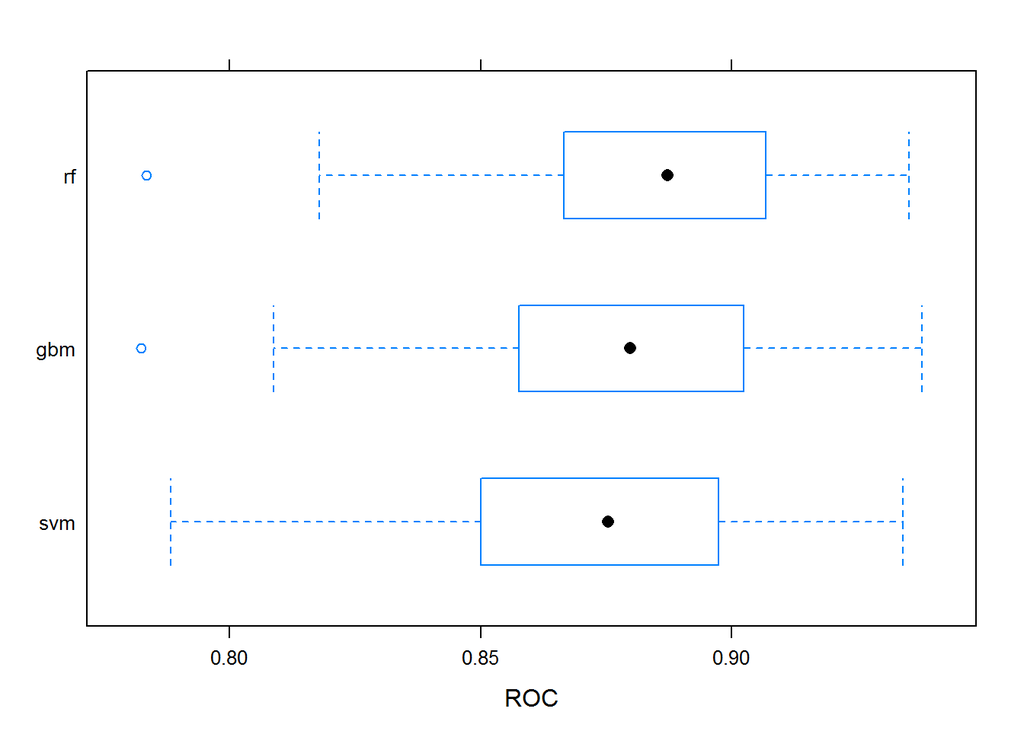

```r
bwplot(rValues,metric="ROC")            # boxplot
```

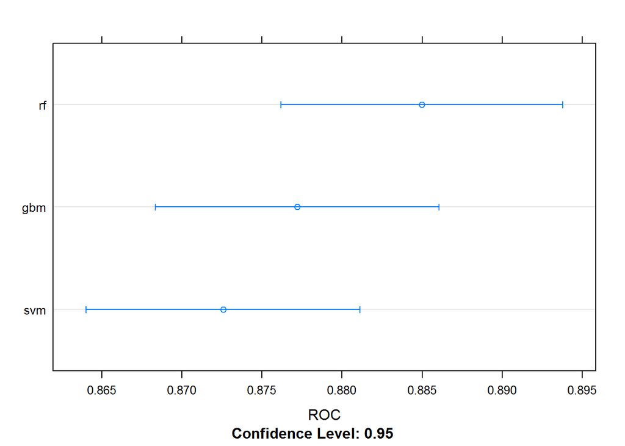

```r
dotplot(rValues,metric="ROC")           # dotplot
```

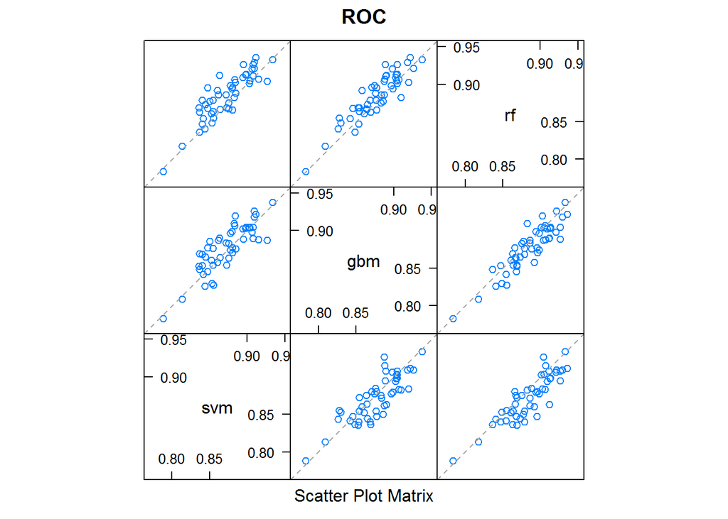

```r
splom(rValues,metric="ROC")
```